# BIOS 667 - Lecture 7: Modeling the Covariance (Ch. 7)

## Fit $\Sigma$ Candidates

```r
# UN with heterogeneous variances
gls_un <- gls(y ~ group * time_f, data = long,
              correlation = corSymm(value = start_vec_un, form = ~ time_idx | id),
              weights     = w_time,
              method      = "REML")

# Compound Symmetry (homoscedastic)
gls_cs <- gls(y ~ group * time_f, data = long,
              correlation = corCompSymm(form = ~ 1 | id),
              method      = "REML")

# AR(1) with equal spacing
gls_ar1 <- gls(y ~ group * time_f, data = long,
               correlation = corAR1(form = ~ time_idx | id),
               method      = "REML")

# Exponential (continuous-time)
gls_exp <- gls(y ~ group * time_f, data = long,
               correlation = corExp(form = ~ time_num | id),
               method      = "REML")

# Exponential with heterogeneous variances
gls_exp_het <- gls(y ~ group * time_f, data = long,
                   correlation = corExp(form = ~ time_num | id),
                   weights     = w_time,
                   method      = "REML")

# Exponential + nugget
gls_exp_nug <- gls(y ~ group * time_f, data = long,
                   correlation = corExp(form = ~ time_num | id, nugget = TRUE),
                   method      = "REML")
```

## Fit $\Sigma$ Candidates

## Parameter Explosion with UN

```r
n <- 2:10
params_UN <- n*(n+1)/2
params_AR1 <- rep(2, length(n))
params_CS  <- rep(2, length(n))
df <- data.frame(n, UN=params_UN, AR1=params_AR1, CS=params_CS) |>
  tidyr::pivot_longer(-n, names_to="model", values_to="p")

ggplot(df, aes(n, p, color=model)) +
  geom_line() + geom_point() +
  labs(title="Number of covariance parameters vs visits",
       x="Number of visits (n)", y="Number of parameters") +
  theme_minimal()
```

## Parameter Explosion with UN

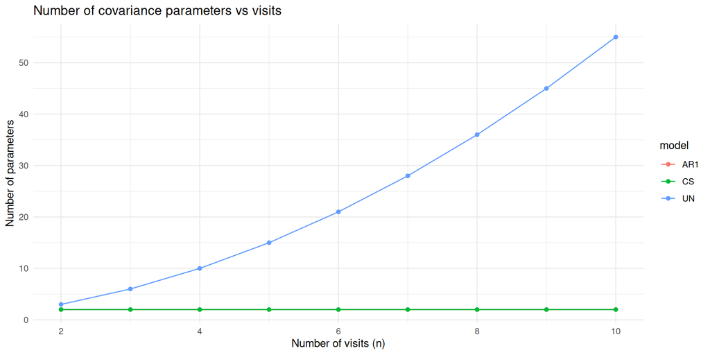

## Parameter Growth vs. Usable $N$

Rule-of-thumb: Be wary if $N$ / #cov-params $\lesssim 5$.

```r
N <- dplyr::n_distinct(long$id)
df2 <- df |>
  tidyr::pivot_wider(names_from = model, values_from = p) |>
  dplyr::mutate(N = N,
         N_per_param_UN = N/UN,
         N_per_param_AR1 = N/AR1,
         N_per_param_CS  = N/CS)
df2
```

## Parameter Growth vs. Usable $N$

```
# A tibble: 9 × 8
      n    UN   AR1    CS     N N_per_param_UN N_per_param_AR1 N_per_param_CS
  <int> <dbl> <dbl> <dbl> <int>          <dbl>           <dbl>          <dbl>
1     2     3     2     2   100          33.3               50             50
2     3     6     2     2   100          16.7               50             50
3     4    10     2     2   100          10                 50             50
4     5    15     2     2   100           6.67              50             50
5     6    21     2     2   100           4.76              50             50
6     7    28     2     2   100           3.57              50             50
7     8    36     2     2   100           2.78              50             50
8     9    45     2     2   100           2.22              50             50
9    10    55     2     2   100           1.82              50             50
```

## UN: Implied Correlation Heatmap

```r
library(reshape2)

# Correlation matrix from UN (first subject)
C_un_list <- corMatrix(gls_un$modelStruct$corStruct)
C_un <- if (is.list(C_un_list)) C_un_list[[1]] else C_un_list

dfC <- melt(C_un)
ggplot(dfC, aes(Var1, Var2, fill = value)) +
  geom_tile() + coord_equal() +
  scale_fill_gradient2(limits = c(-1,1)) +
  labs(title = "Implied correlation (UN)", x = "Visit index (1..4)", y = "Visit index (1..4)", fill = "rho") +
  theme_minimal()
```

## UN: Implied Correlation Heatmap

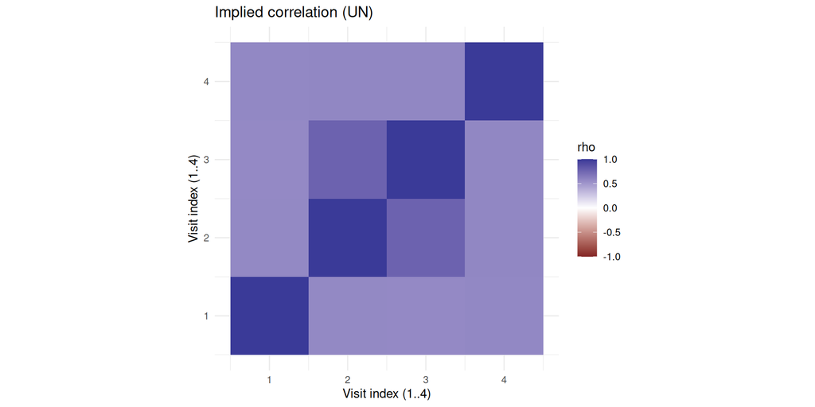

## UN: Residual SD by Time

```r
# varIdent returns relative SD multipliers by factor level (base level=1)
w_coef <- coef(gls_un$modelStruct$varStruct, unconstrained = FALSE)
levs <- levels(long$time_f)
w_all <- setNames(rep(1, length(levs)), levs)
w_all[names(w_coef)] <- w_coef

sigma_eps <- sigma(gls_un)
sd_time <- sigma_eps * w_all

data.frame(time = names(sd_time), sd = as.numeric(sd_time)) %>%
  ggplot(aes(x = time, y = sd, group = 1)) +
  geom_line() + geom_point(size = 2) +
  labs(title = "Estimated residual SD by time (UN + varIdent)",
       x = "Time (weeks)", y = "SD") +
  theme_minimal()
```

## UN: Residual SD by Time

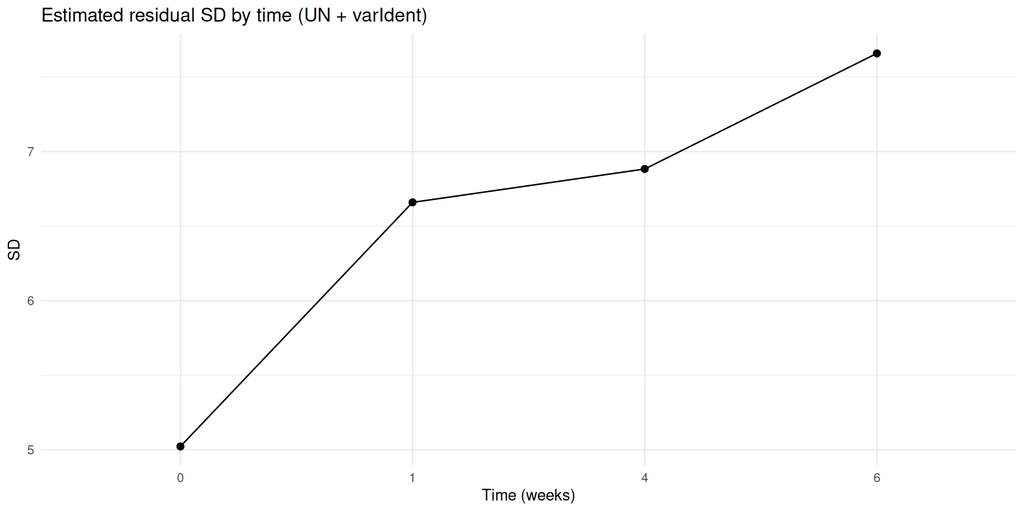

## UN Takeaways

| Strength | Limitation |
| --- | --- |
| Flexible | Parameter count grows quickly |
| Captures non-constant variances | Requires ample $N$ relative to $n(n+1)/2$ |
| Captures irregular pairwise correlations | Not ideal for mistimed visits |

**Check Your Understanding: Unstructured Covariance**

1. How many covariance parameters does the UN model require for a study with 6 planned visits?
2. A colleague fits UN to a dataset with $N = 50$ subjects and 8 visits. Should they be concerned? Why?
3. What does the “varIdent” component add on top of the correlation structure in `gls`?

**Answers:**

1. $n(n+1)/2 = 6(7)/2 = 21$ parameters.
2. Yes, definitely. With 8 visits, UN requires $8(9)/2 = 36$ covariance parameters. The rule of thumb is $N$/params $\gtrsim 5$, so they would need at least $36 \times 5 = 180$ subjects. With only 50 subjects, the ratio is about 1.4, which risks unstable estimates.
3. The `corSymm` structure models the correlation matrix (values between -1 and 1), while `varIdent` allows heterogeneous variances across time points. Together, they model the full covariance matrix with time-varying SDs.

## UN Failure Modes & Remedies

| Failure Mode | Remedy |
| --- | --- |
| Non-positive-definite estimates | Use structured $\Sigma$ (AR(1), Toeplitz, Exponential) |
| Non-convergence | Increase optimizer iterations/tolerance |
| Inflated SEs when $N$ is small | Simplify mean model |
| Overfit | Consider mixed-effects (RI/RS; Chapter 8) |